# 第2回 データ前処理（読込・グラフ化）

経済データとプログラミングII

第2回

データ前処理

見て、直して、形をそろえる

経済データとプログラミングII

第2回 — Topic01

データの読み込みと表の大きさ

表の 1 行は何を表す？

## 第2回の道のり

1

読み込みと大きさ

演習 2-1

見出し行の読み飛ばし

2

型と欠損

演習 2-2

欠損の数え方

3

ヒストグラム

演習 2-3

区間の数え直し

4

箱ひげ図と外れ値

演習 2-4

真ん中の値と中央値

いまココ — 表の 1 行の意味と、表の大きさを確かめる

## 前の回の振り返り

前の回のポイント

Q: `fit(X, y)` に渡した $X$ と $y$ は、誰が作ったのか

- **3 行で動いた**: モデルを作る → `fit` で学ぶ → `predict` で予測
- **良さの物差し**: 手元の当てはまりではなく、未知のデータへの性能
- **見えていなかったこと**: あの $X$ と $y$ は、すでに整えられたものだった

今日はその手前。データを読んで、自分の目で確かめる

## このトピックで学ぶこと

- **何をやるか**：表の 1 行の意味・2 段の見出しの読み方・表の大きさ
- **なぜ**：読み違えたまま、平均や図へ進まないため
- **いつ必須か**：新しい CSV を開くたび、毎回
- **最後に**：自分の Colab で同じ表を読み、大きさを見る

問い：北海道の人口は、2022 年から 2023 年でどう変わった？

## 表の 1 行と 1 列の意味

[figure not shown]

上の行が新しい年。下の 2022 年から上の 2023 年へ、48000 人減った

## SSDSE-B の中身

用語

**SSDSE-B**＝統計センターが作った教育用データの  
都道府県ごとの推移の表

- **作った所**：統計センター。  
  授業で使えるように整えたデータ集 SSDSE の 1 つ
- **中身**：47 都道府県 × 2012〜2023 年。  
  人口・地価・気温・大学生の数など 109 項目
- **名前の 2026**：データの版の名前。観測した年ではない

表全体でも、1 行＝ある県のある年

## 見出しが 2 段の小さな CSV

[figure not shown]

行の番号は 0 から数える。0 番が列の名前、1 番は読まない

## 本物の CSV の先頭

今度は**本物のファイル**。同じ 0・1・2 番の役目を、同じ順に指す

[figure not shown]

記号の名前だけでは中身が分からない。だから 1 番に日本語の名前がある

## データを読む準備のセル

```python
import pandas as pd
BASE = "（データの URL）"
```

| 行 | 書き方 | 意味 |
| --- | --- | --- |
| 1 | `import pandas as pd` | 表を扱う道具 pandas を、`pd` の名前で呼ぶ |
| 2 | `BASE = "…"` | データの置き場所に `BASE` の名前。 変えるのはこの 1 行だけ |

**写経せず、そのまま実行するセル**  
データの URL は manaba に。CSV を上げた人は `""` のまま  
入れ方は配布資料「Colab へのデータの入れ方」

## 写経 1 の 4 つの部品

```python
df = pd.read_csv(BASE + "SSDSE-B-2026.csv",
                 header=0, skiprows=[1])
df = df.rename(columns={df.columns[0]: "year",
                        df.columns[1]: "code",
                        df.columns[2]: "prefecture"})
df.head(3)
```

| 行 | 部品 | 渡すもの | 返ってくるもの・起きること |
| --- | --- | --- | --- |
| 1 | **① 読み込む** | 置き場所とファイル名 | 表が返り、`df` の名前 |
| 2 | **② 見出しの指定** | `header=0` と `skiprows=[1]` | 0 番が列の名前、1 番は読まない |
| 3-5 | **③ 名前の付け直し** | 先頭 3 列の新しい名前 | 列の名前が year・code・ prefecture に |
| 6 | **④ 先頭を見る** | 見る行の数 `3` | セルの下に先頭の 3 行が出る |

※ `df.columns[0]` は 0 番目の列。  
今の名前は `SSDSE-B-2026` で、年の列と分からない  
※ **`"` は半角。全角の `”` だとエラー**

## コードセルの写経と実行

1. **＋ コード**で空のセルを足す  
   （案内の文の下）
2. 写経 1 の 6 行を上  
   から写す
3. **▶** か **Shift + Enter** で実行  
   （Mac は Shift + return）
4. 表の 0 行目が 2023 年の  
   北海道かを見る

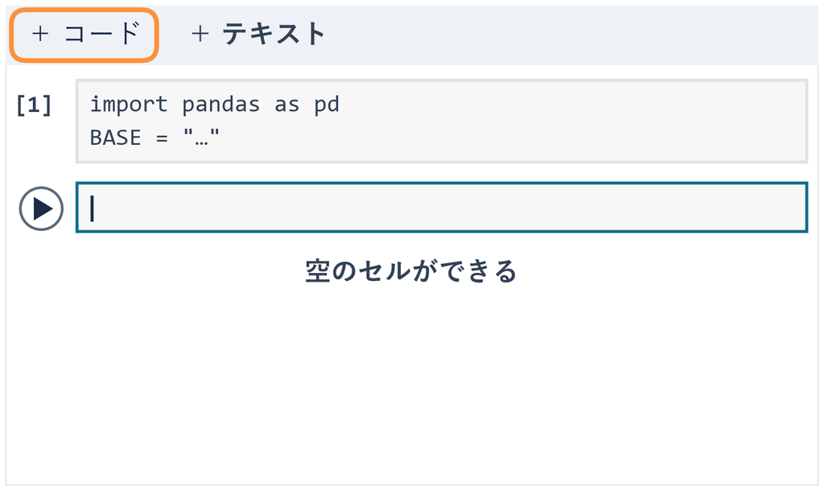

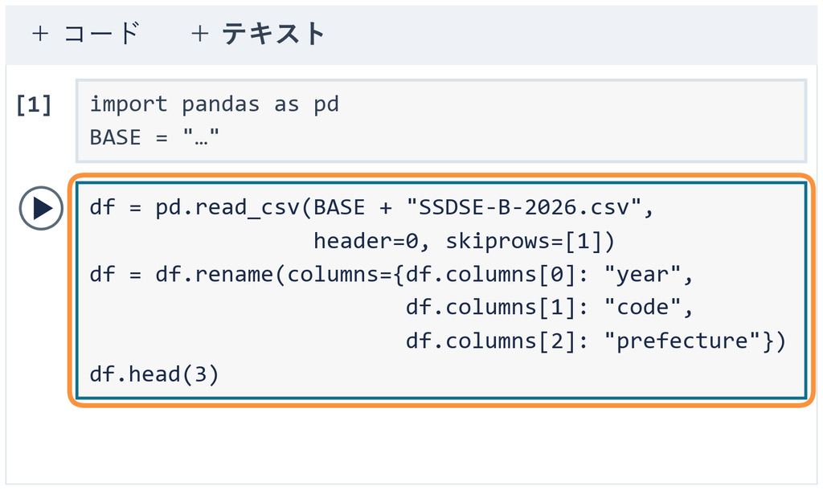

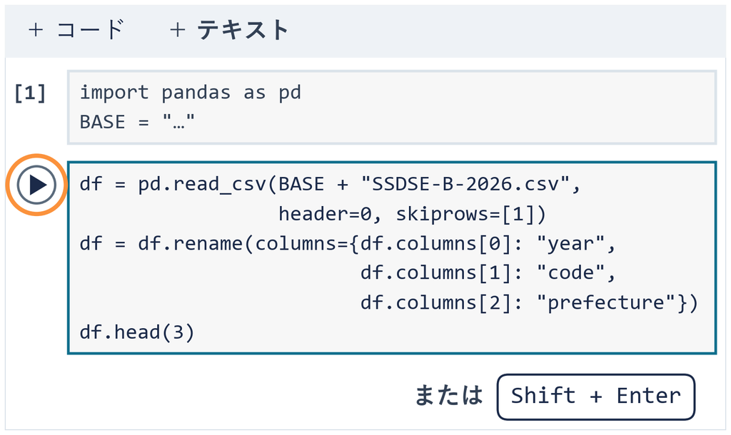

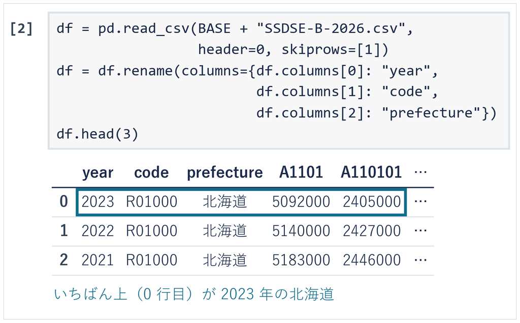

⏸ PAUSE 動画を止めて $2$ 分。表が出たら再生に戻る

## 写経 1 の出力

[figure not shown]

列の名前は year・code・prefecture。0 行目は 2023 年の北海道

## 演習 2-1 見出し行の読み飛ばし

演習 2-1

`skiprows=[1]` を消すと、`head(3)` の 0 行目には何が並ぶか

```python
bad = pd.read_csv(BASE + "SSDSE-B-2026.csv", header=0, skiprows=[1])
bad.head(3)
```

1. **先に考える**：ⓐ 2023 年の北海道  
   ⓑ 年度・地域コード・都道府県・総人口
2. **写して消す**：案内の下に **＋ コード** でセルを足し、写す  
   `, skiprows=[1]` を消して実行（1 か所）。写経のセルは残す
3. **終わり**：答え欄に ⓐ か ⓑ を書く ※ `"` は半角

⏸ PAUSE 動画を止めて $3$ 分。答えを書いたら再生に戻る

## 演習 2-1 の答え

答えは **ⓑ**。読まないはずの日本語の行が、データの 0 行目に入る

[figure not shown]

**よくある失敗**：2 段目も見出しに見えるので、`skiprows` をつい忘れる

## 表の大きさの数え方

数え方

**大きさ**＝（行の数, 列の数）。先が行、後が列  
列の名前の行と、左の行番号は数えない

[figure not shown]

## 実データの表の大きさ

今度は**本物の表**。同じ数え方で、行と列を数える

[figure not shown]

## 写経 2 の表の大きさのコード

```python
print(df.shape)
```

| 行 | 部品 | 渡すもの | 返ってくるもの・起きること |
| --- | --- | --- | --- |
| 1 | **① 大きさ** `df.shape` | 表 `df` | （行の数, 列の数）の組 |
| 1 | **② 表示** `print()` | 出したいもの | セルの下に出る |

写経 2 の案内の下に、新しいセルを足して 1 行を写す  
※ `shape` の後ろに `()` は付けない

## 表の大きさの写経と実行

1. **＋ コード**でセルを足す  
   （案内の文の下）
2. `print(df.shape)`  
   の 1 行を写す
3. **▶** か **Shift + Enter** で実行  
   （Mac は Shift + return）
4. セルの下に (564, 112)  
   が出るかを見る

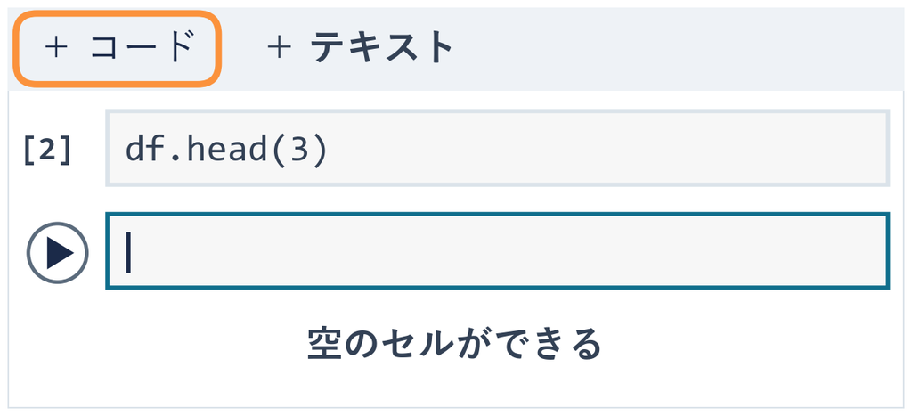

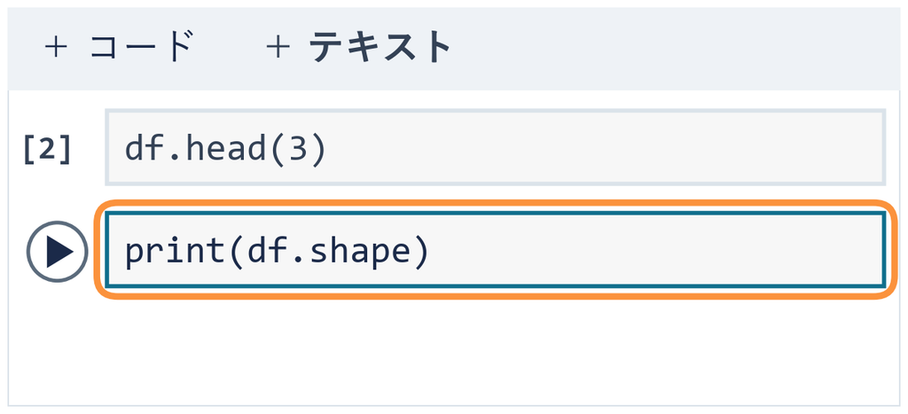

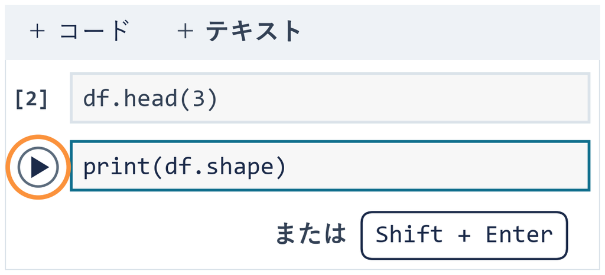

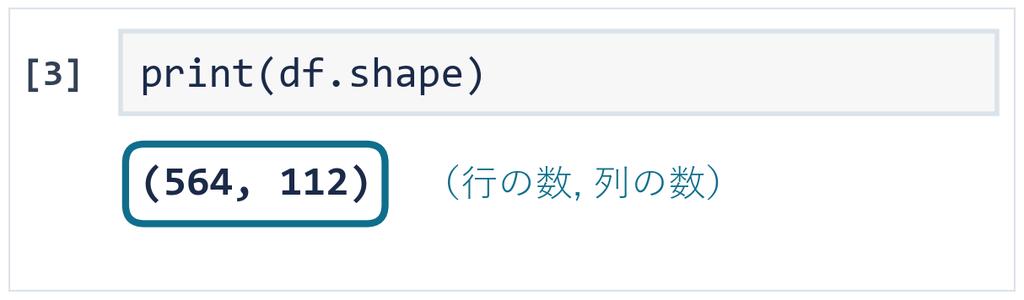

⏸ PAUSE 動画を止めて $1$ 分。2 つの数が出たら再生に戻る

## ✋ たしかめ 読み飛ばしと表の大きさ

たしかめ

演習 2-1 で作った表 `bad` の大きさは、どれか

1. 予想を 1 つ選ぶ — ⓐ (564, 112) ⓑ (565, 112) ⓒ (564, 113)
2. 日本語の行は、行と列のどちらに数えられたかを考える

⏸ PAUSE 動画を止めて $1$ 分。PC は使わない。予想を決めたら再生に戻る

## たしかめの答え

答えは **ⓑ (565, 112)**。日本語の行が、データの 1 行に数えられた

[figure not shown]

確かめるなら、別のセルで `print(bad.shape)` を実行する

## まとめ

- 表の 1 行＝ある県のある年。1 列＝1 つの項目
- 行の番号は 0 から。`header=0` で 0 番を列の名前にする
- 2 段目の日本語の行は、`skiprows=[1]` で読まない
- 大きさは（行の数, 列の数）。見出しの行は数えない
- この表は (564, 112)。564 ＝ 47 都道府県 × 12 年

バイト先で渡された売上の表も、まず 1 行の意味と大きさを確かめる  
機械に渡す前に、データを自分の目で確かめる

経済データとプログラミングII

第2回 — Topic02

データ型と欠損の確認

数として読めている？

## 第2回の道のり

1

読み込みと大きさ

演習 2-1

見出し行の読み飛ばし

2

型と欠損

演習 2-2

欠損の数え方

3

ヒストグラム

演習 2-3

区間の数え直し

4

箱ひげ図と外れ値

演習 2-4

真ん中の値と中央値

いまココ — 列の型と、空欄の数を確かめる

## このトピックで学ぶこと

- **何をやるか**：型（数か文字か）と欠損（空欄）を確かめる
- **なぜ**：文字のままでは計算できない。空欄は目で見つけにくい
- **いつ必須か**：表を読み込んだ直後に、毎回
- **最後に**：欠損の数え方を、自分のノートで確かめる

問い：表の 5092000 は、数として読めている？

## 数としての並べ替え

[figure not shown]

3 つの値を、数として小さい順に並べると 9・10・100

## ✋ たしかめ 文字としての並べ替え

たしかめ

同じ 3 つを文字として小さい順に並べると、いちばん上はどれか

1. 予想を 1 つ選ぶ — ⓐ 9 ⓑ 10 ⓒ 100
2. 1 文字目どうしを比べると、どうなるかを考える

⏸ PAUSE 動画を止めて $1$ 分。PC は使わない。予想を決めたら再生に戻る

## 文字の並べ替えの答え

答えは **ⓑ 10**。文字は 1 文字目から順に比べる

[figure not shown]

## 型の読み方

用語

**型**＝列の値を、数として扱うか、文字として扱うかの印  
列ごとに 1 つ決まる

- **int64**：整数の列。総人口の 5092000 など
- **float64**：小数も入る数の列
- **str**：文字の列。都道府県の名前など

※ pandas の版によっては、str ではなく object と出る

## 実データの列の型

今度は**本物の表**。県名の列と総人口の列の型を見る

[figure not shown]

※ pandas の版によっては、str ではなく object と出る

## 写経 1 の型を見るコード

```python
part = df[["prefecture", "A1101"]]
print(part.head(3))
print(part.dtypes)
```

| 行 | 部品 | 渡すもの | 返ってくるもの・起きること |
| --- | --- | --- | --- |
| 1 | **① 列を取り出す** | 列の名前を `[ ]` に並べる | 2 列の表が返り、`part` の名前 |
| 2 | **② 先頭を見る** `head(3)` | 見る行の数 `3` | セルの下に先頭の 3 行が出る |
| 3 | **③ 型を見る** `dtypes` | 何も渡さない | 列ごとの型が 1 行ずつ出る |

※ `[[` `]]` は 2 重。内側が列の名前の並び  
※ `dtypes` の後ろに `()` は付けない ※ **`"` は半角**

## 型を見るコードの写経と実行

1. **＋ コード**でセルを足す  
   （案内の文の下）
2. 写経 1 の 3 行を上  
   から写す
3. **▶** か **Shift + Enter** で実行  
   （Mac は Shift + return）
4. 型の 2 行が str と int64  
   かを見る

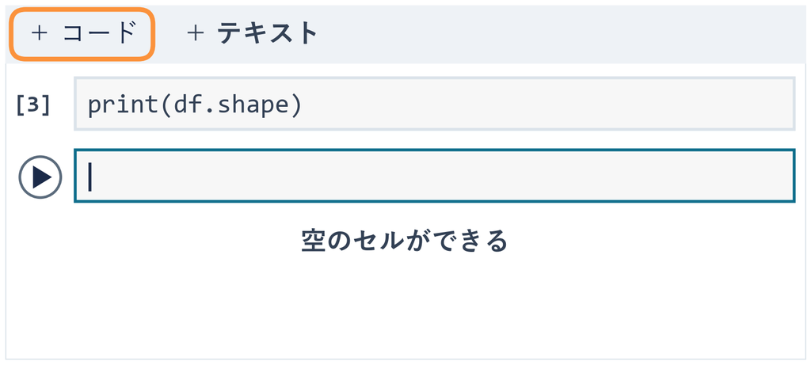

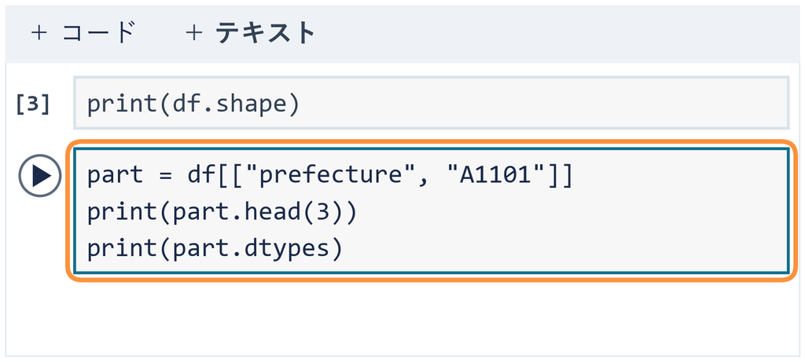

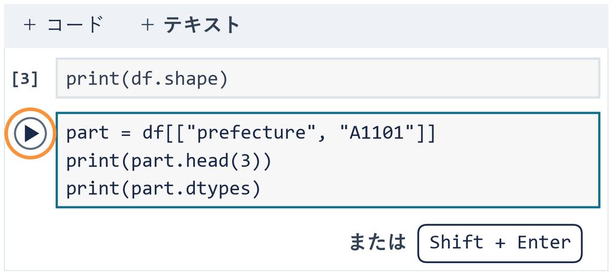

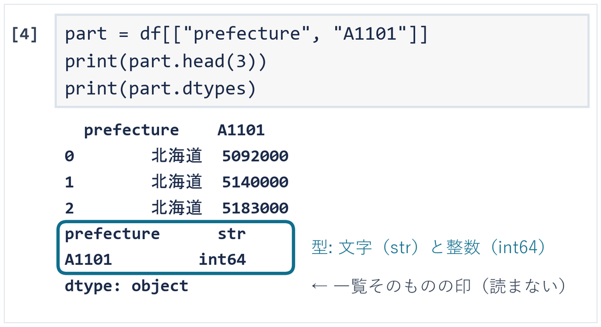

⏸ PAUSE 動画を止めて $2$ 分。型の 2 行が出たら再生に戻る

※ `df` が無いと出たら、ノートの最初のセルから実行し直す

## ✋ たしかめ 読み飛ばし忘れと型

たしかめ

演習 2-1 で作った表 `bad` では、A1101 の型はどちらか

1. 予想を 1 つ選ぶ — ⓐ int64 ⓑ str
2. `bad` の A1101 の 0 行目に、何が入っていたかを考える

⏸ PAUSE 動画を止めて $1$ 分。PC は使わない。予想を決めたら再生に戻る

## 読み飛ばし忘れと型の答え

答えは **ⓑ str**。**文字が 1 つでも混ざると、列ぜんぶが文字**

[figure not shown]

確かめるセル：`print(bad.dtypes.value_counts())` → 出力は `str 112`

## 空欄のある小さな表

[figure not shown]

`isnull()` で空欄だけが True。列ごとに True を数えると 0・1・1

## 欠損の印と合計

用語

**欠損**＝値が入っていない所。pandas ではふつう NaN と出る

- **`isnull()`**：欠損なら True、値があれば False の表を返す
- **`.sum()`**：True は 1・False は 0 として、列ごとに足す
- **もう一度 `.sum()`**：列ごとの数を足して、表ぜんぶの数に

0 は欠損ではない。0 という値が入っている

## 実データの欠損の数

今度は**本物の表**の 3 列。同じ順に、True／False にしてから数える

[figure not shown]

## 写経 2 の欠損を数えるコード

```python
part = df[["A1101", "C5401", "E6302"]]
blank = part.isnull()
print(blank.sum())
```

| 行 | 部品 | 渡すもの | 返ってくるもの・起きること |
| --- | --- | --- | --- |
| 1 | **① 列を取り出す** | 3 つの列の名前 | 3 列の表が返り、`part` の名前 |
| 2 | **② 空欄か** `isnull()` | 何も渡さない | True／False の表に `blank` の名前 |
| 3 | **③ 数える** `sum()` | 何も渡さない | 列ごとの True の数が出る |

①〜③ は、5 人の表で見た 3 段と同じ順  
※ **`"` は半角。全角の `”` だとエラー**

## 欠損を数えるコードの写経と実行

1. **＋ コード**でセルを足す  
   （案内の文の下）
2. 写経 2 の 3 行を上  
   から写す
3. **▶** か **Shift + Enter** で実行  
   （Mac は Shift + return）
4. 0 が 3 つ並ぶかを見る

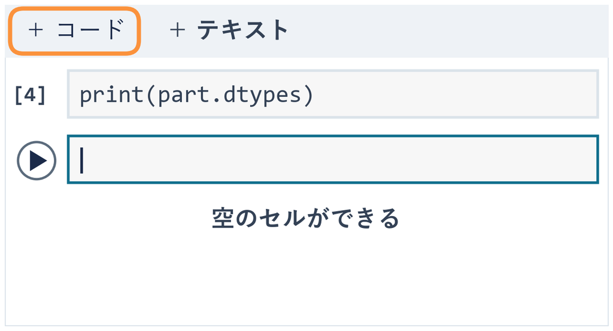

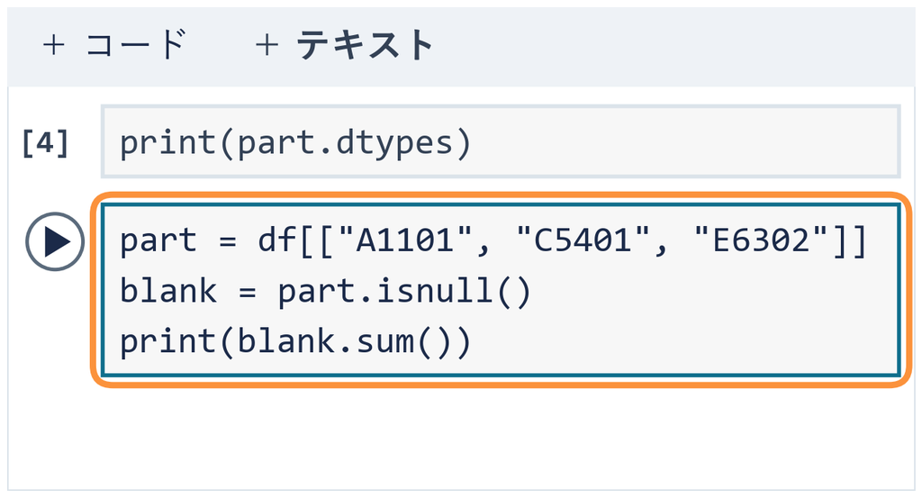

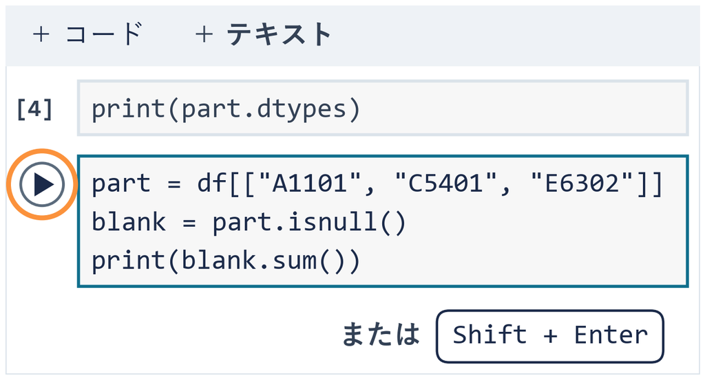

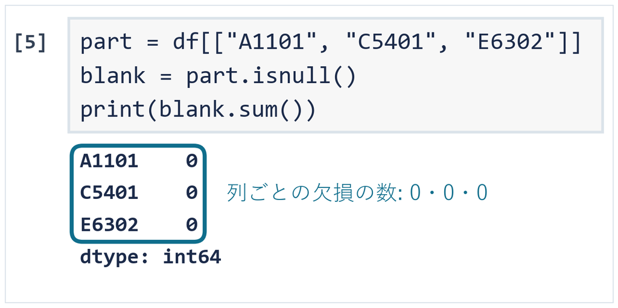

⏸ PAUSE 動画を止めて $2$ 分。0 が 3 つ出たら再生に戻る

## 写経 3 の空欄を作るコード

```python
import numpy as np
toy = pd.DataFrame({"名前": ["A", "B", "C", "D", "E"],
                    "通学": [30, np.nan, 20, 40, 10],
                    "バイト": [8, 12, np.nan, 0, 6]})
blank = toy.isnull()
print(blank.sum())
```

| 行 | 部品 | 渡すもの | 返ってくるもの・起きること |
| --- | --- | --- | --- |
| 1 | **① 準備** `import` | 使う道具の名前 | `np` の名前で numpy が使える |
| 2 | **② 表を作る** `DataFrame` | 列の名前と、値の並び | 5 人の表が返り、`toy` の名前 |
| 3 | **③ 空欄** `np.nan` | 何も渡さない | 値の入っていない所になる |
| 5 | **④ 空欄か** `isnull()` | 何も渡さない | True／False の表に `blank` の名前 |
| 6 | **⑤ 数える** `sum()` | 何も渡さない | 列ごとの True の数が出る |

2〜4 行目で 1 つの命令。④⑤ は写経 2 と同じ  
※ **`"` は半角**。列の名前だけ日本語で打つ

## 空欄を作るコードの写経と実行

1. **＋ コード**でセルを足す  
   （案内の文の下）
2. 写経 3 の 6 行を上  
   から写す
3. **▶** か **Shift + Enter** で実行  
   （Mac は Shift + return）
4. 0・1・1 が並ぶかを見る

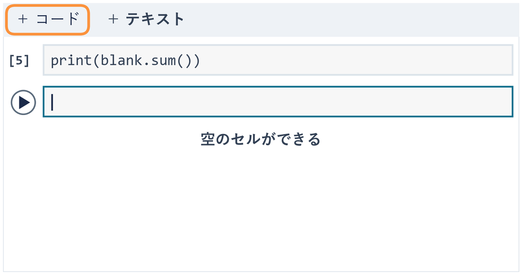

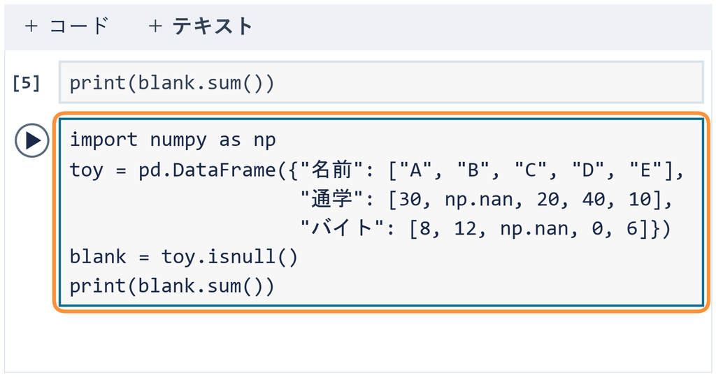

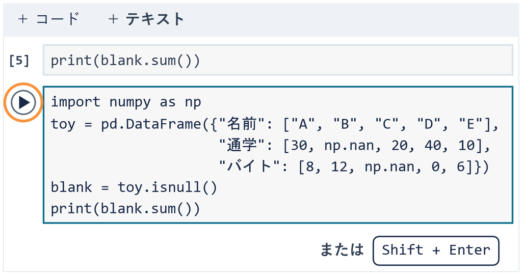

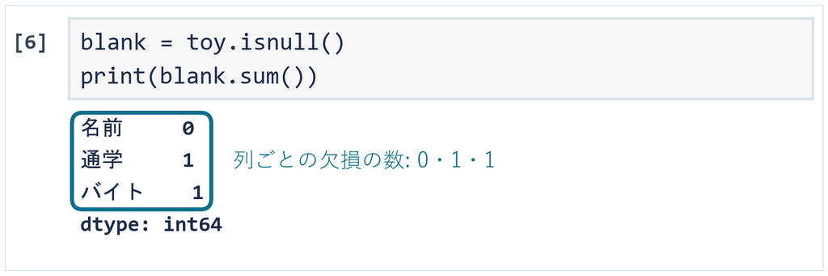

⏸ PAUSE 動画を止めて $2$ 分。0・1・1 が出たら再生に戻る

## 演習 2-2 欠損の数え方

演習 2-2

先頭 5 列が全部 0 なら、112 列ぜんぶ 0 と言えるか

```python
blank = df.isnull()
print(blank.sum().head())
```

1. **先に考える**：ⓐ 言える ⓑ 言えない。何列ぶんを見たかで
2. **写して実行**：案内の下に **＋ コード** でセルを足し、写したまま実行
3. **1 か所変える**：2 行目の `.head()` を `.sum()` にして、もう一度実行
4. **終わり**：答え欄に ⓐ か ⓑ と、出た数を書く

⏸ PAUSE 動画を止めて $3$ 分。答えを書いたら再生に戻る

## 演習 2-2 の答え

答えは **ⓑ 言えない**。`head()` が見せたのは 5 列だけ

[figure not shown]

**よくある失敗**：見えた 5 列だけで「全部 0」と言い切る

## まとめ

- 型は、列の値を数として扱うか文字として扱うかの印
- 文字の列は 1 文字目から比べる。10・100・9 の順になる
- 文字が 1 つでも混ざると、列ぜんぶが文字になる
- `isnull()` で空欄だけ True、`.sum()` で列ごとに数える
- 表ぜんぶを確かめるなら、もう一度 `.sum()` で足す

機械に渡す前に、データを自分の目で確かめる

経済データとプログラミングII

第2回 — Topic03

ヒストグラムと探索的  
データ分析

値はどこに集まる？

## 第2回の道のり

1

読み込みと大きさ

演習 2-1

見出し行の読み飛ばし

2

型と欠損

演習 2-2

欠損の数え方

3

ヒストグラム

演習 2-3

区間の数え直し

4

箱ひげ図と外れ値

演習 2-4

真ん中の値と中央値

いまココ — 値がどこに集まるかを、棒の図で読む

## このトピックで学ぶこと

- **何をやるか**：値を区間に分けて数え、棒の図にする
- **なぜ**：平均 1 つでは、値の集まり方と広がりが見えない
- **いつ必須か**：数の列を初めて見るとき、毎回
- **最後に**：同じ図を Python で描き、1 か所だけ変えて確認

問い：6 人の通学時間。平均だけで説明してよい？

## 6 人の通学時間と平均

[figure not shown]

説明用の架空データ。平均 1 つでは、10 分の人も 40 分の人も見えない

## ◼ 区間と度数

定義

**区間**

＝ 値の範囲を「〜以上〜未満」で区切ったもの

（**境目ちょうどの値**は、右の区間に入れる）

**度数**

＝ 1 つの区間に入った値の数

- 例：20 分は「20 以上 40 未満」の区間。「0 以上 20 未満」には入らない
- 区間の幅は、どれも同じにそろえる

注：Python の hist は、いちばん右の区間だけ右端の値も含む（今回のデータには無い）

## ◼ ヒストグラムの作り方

手順

**STEP 1** 最小と最大を見て、**区間の端**を決める  
**STEP 2** 値を 1 つずつ、入る**区間**に数える（境目は右へ）  
**STEP 3** 区間ごとの**度数**を、**棒の高さ**にする

次のページから、6 人の例で STEP 1 から順に作る

## STEP 1 区間の端の決め方

式

端は、最小から最大までが入るように、同じきざみで並べる  
区間の数 ＝ 端の数 − 1

**今回は**（6 人の値は 10 〜 40 分）

$\text{端} = 0,\ 20,\ 40,\ 60$

20 分きざみ。10 も 40 も入る

$\text{区間の数} = 4 - 1 = 3$

端 4 つのあいだが 3 つ

※ 20 分きざみなら、区間が 3 つで数えやすい

## STEP 2・3 区間ごとの人数と棒

[figure not shown]

**境目ちょうどの値は右の区間へ**

## ヒストグラムの読み方

用語

**ヒストグラム**＝区間ごとの度数を、棒の高さにした図

- **横軸**：値の区間。6 人なら通学時間（分）
- **縦軸**：度数。6 人なら区間に入った人数
- **読むもの**：値がどこに集まり、どこまで広がるか

6 人なら 20〜40 分に 3 人が集まり、40〜60 分に 1 人

## 年平均気温の表

今度は**都道府県の年平均気温**。2023 年の 47 行を数える

| 都道府県 | B4101（℃） |
| --- | --- |
| 北海道 | 11.0 |
| 青森県 | 12.6 |
| 岩手県 | 12.5 |
| ⋮ | ⋮ |
| 沖縄県 | 23.8 |

横軸は 分 → ℃、縦軸は 人数 → 都道府県の数

今回は 最小 11.0・最大 23.8 →

10〜25℃ を 1℃ きざみ

$\text{端の数} = 25 - 10 + 1 = 16$

$\text{区間の数} = 16 - 1 = 15$

## 年平均気温のヒストグラム

[figure not shown]

6 人と同じ順に読む。16〜18℃ に 26 県が集まり、沖縄県だけが離れる

## デモ：区間の幅の実験室

数え方

区間は「〜以上〜未満」。  
10〜25℃ を選んだ幅で区切って数える

- **何を見るか**：47 都道府県の気温。区間の幅だけを変える
- **図の意味**：左は棒の図、右は区間の数と高さの合計
- **操作**：幅のタブ 1℃・3℃・5℃・戻す

ミッション 沖縄県の棒と、  
ほかの棒のあいだに高さ 0 の区間ができる幅を探す

※ 次のスライドへ進むときは、デモの枠の外を一度クリックしてから ← → キーを押す

[interactive chart not shown]

## 探索的データ分析の考え方

用語

**探索的データ分析（EDA）**＝表・要約・図を行き来して  
データの特徴や、確かめたい点を探すこと

- **要約**：47 県を足して 47 で割った平均は約 16.8℃。  
  これだけでは集まり方が見えない
- **図**：16〜18℃ に 26 県が集まり、離れた棒が 1 本ある
- **表**：離れた棒は沖縄県。表の 23.8℃ で確かめる

見つけても、すぐ直すとは限らない。沖縄県は本当に暖かい

## 図を描く準備のセル

```python
!pip install japanize-matplotlib
import japanize_matplotlib
import matplotlib.pyplot as plt
```

ノートの上にある**準備のセル**。そのまま 1 回実行する  
1〜2 行目：図の日本語を出す 3 行目：図の道具を `plt` と呼ぶ  
このあとの写経の `plt.` は、この 3 行目の `plt`

## 写経 1 の 5 つの部品

```python
data = [10, 10, 20, 20, 20, 40]
fig, ax = plt.subplots()
ax.hist(data, bins=[0, 20, 40, 60], edgecolor="black")
ax.set_xlabel("通学時間（分）")
ax.set_ylabel("人数")
plt.show()
```

| 行 | 部品 | 渡すもの | 返ってくるもの・起きること |
| --- | --- | --- | --- |
| 1 | **① データを用意** | 6 人の分を `[ ]` に並べる | 6 個の並びに `data` の名前 |
| 2 | **② 図の枠** | 何も渡さない | 図の全体 `fig` と描く場所 `ax` |
| 3 | **③ ヒストグラムを置く** | `data` と区間の端 `bins` | `ax` に棒が入る |
| 4-5 | **④ 軸名** | 横軸と縦軸に書く文字 | 2 つの軸に名前が付く |
| 6 | **⑤ 表示** | 何も渡さない | セルの下に図が出る |

※ `bins` は区間の端 4 つ＝区間 3 つ。`edgecolor` は棒の縁の色  
※ **`"` は半角。全角の `”` だとエラー**

## コードセルの写経と実行

1. **＋ コード**で空の  
   セルを足す
2. 写経 1 の 6 行を上  
   から写す
3. **▶** か **Shift + Enter** で実行  
   （Mac は Shift + return）
4. セルの下の図で、棒の高  
   さ 2・3・1 を確かめる

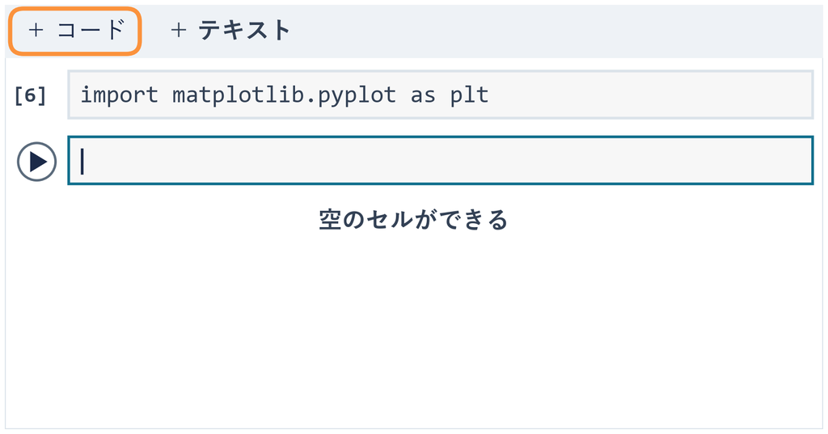

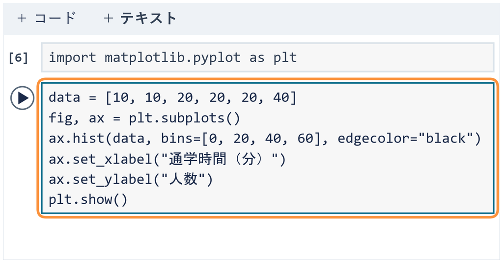

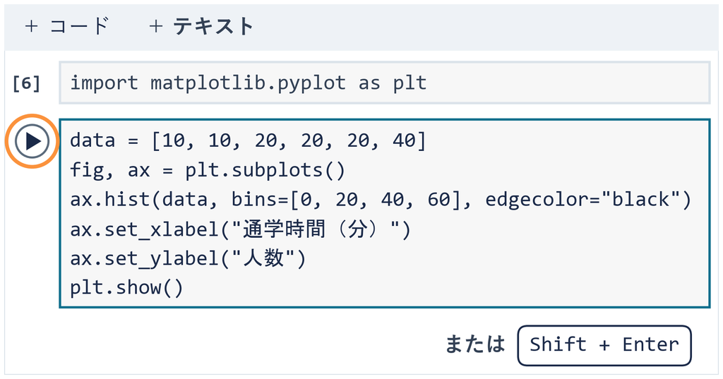

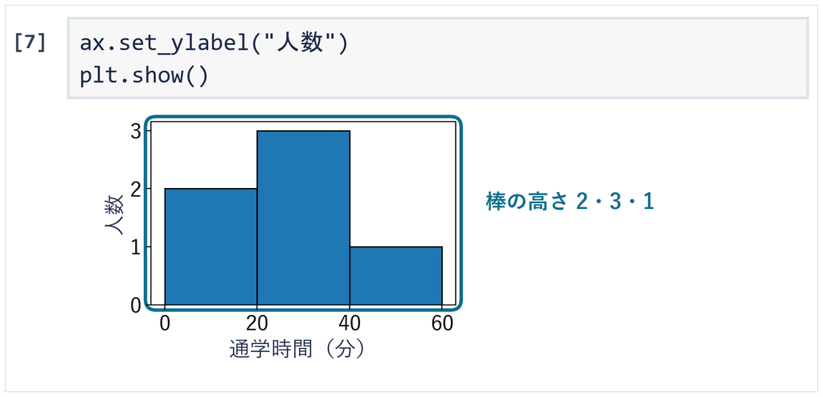

⏸ PAUSE 動画を止めて $2$ 分。図が出たら再生に戻る

## 実データの取り出し

```python
cs = df[df["year"] == 2023]
print(len(cs), "行")
cs[["prefecture", "B4101"]].head(3)
```

| 行 | 書き方 | 意味 |
| --- | --- | --- |
| 1 | `df[df["year"] == 2023]` | `==` で「年が 2023 と等しいか」を行ごとに調べ、 合う行だけ取り出して `cs` の名前 |
| 2 | `len(cs)` | 行の数を数える。47 県なので `47 行` と出る |
| 3 | `[["prefecture", "B4101"]]` | 県名と気温の 2 列を選ぶ。 続く `.head(3)` で先頭の 3 行を見る |

**写経せず、そのまま実行するセル**。`df` は最初に読んだ SSDSE-B の表  
※ `==` は「等しいか」を比べる記号。名前を付ける `=` とは別  
※ 出力の左の 0・12・24 は元の表の行番号（1 県 12 年分で 12 行おき）

## 写経 2 の気温のコード

```python
data = cs["B4101"]
fig, ax = plt.subplots()
ax.hist(data, bins=range(10, 26), edgecolor="black")
ax.set_xlabel("年平均気温（℃）")
ax.set_ylabel("都道府県の数")
plt.show()
```

| 行 | 部品 | 写経 1 から変えたところ |
| --- | --- | --- |
| 1 | **① データ** | 6 人の並び → 列 `B4101` の 47 県 |
| 3 | **③ 区間の端** | `range(10, 26)`＝10〜25 の端 16 個。26 は入らない |
| 4-5 | **④ 軸名** | 分・人数 → ℃・都道府県の数 |

② ⑤ は写経 1 と同じ ※ `"` は半角（全角 `”` はエラー）

⏸ PAUSE 動画を止めて $2$ 分。2 つ目の図が出たら再生に戻る

## 写経 1 と写経 2 の出力

[figure not shown]

同じ 6 行の形で、通学時間の 3 本と、気温の 15 区間が描けた

## 演習 2-3 区間の数え直し

演習 2-3

F さんの 40 分が、じつは 30 分なら、3 本の棒の高さは？

```python
data = [10, 10, 20, 20, 20, 40]
fig, ax = plt.subplots()
ax.hist(data, bins=[0, 20, 40, 60], edgecolor="black")
ax.set_xlabel("通学時間（分）")
ax.set_ylabel("人数")
plt.show()
```

1. **先に考える**：ⓐ 2・3・1 ⓑ 2・4・0 ⓒ 3・3・0。30 はどの区間か
2. **写して変える**：案内の下に **＋ コード** で足して写し、`40` を `30` に
3. **終わり**：答え欄に、選んだ記号と 3 本の高さを書く

⏸ PAUSE 動画を止めて $3$ 分。3 本の高さが読めたら再生に戻る

## 演習 2-3 の答え

F さんを 30 分にして、区間と棒を 1 つずつ確かめる

$\text{F さんの区間}\quad 40$

$\sim 60 \to 20 \sim 40$

30 は 20 以上 40 未満

$\text{真ん中の棒}\quad 3$

$\to 4$

C・D・E の 3 人に F さんが加わる

$\text{右の棒}\quad 1$

$\to 0$

40〜60 分の人がいなくなる

$\text{左の棒}\quad 2$

$\to 2$

A・B の 10 分は動かない

答えは ⓑ 2・4・0  
区間 40〜60 は残り、棒の高さが 0 になる

## 30 分のカードの移動と棒

[figure not shown]

**人がいない区間も残る。棒の高さが 0 になるだけ**

## まとめ

- 区間は「〜以上〜未満」。境目ちょうどの値は右の区間へ
- 棒の高さは、区間に入った値の数（度数）
- 区間の幅で見え方が変わる。1 つの幅だけで決めない
- 表・要約・図を行き来して、確かめる点を探すのが EDA
- コードは 5 つの部品のパズル。変えるのはデータ・区間・軸名

部屋探しで家賃を比べるときも、平均だけでなく棒で見る  
平均 1 つの前に、値がどこに集まるかを確かめる

経済データとプログラミングII

第2回 — Topic04

箱ひげ図と外れ値

離れた点は、消してよい？

## 第2回の道のり

1

読み込みと大きさ

演習 2-1

見出し行の読み飛ばし

2

型と欠損

演習 2-2

欠損の数え方

3

ヒストグラム

演習 2-3

区間の数え直し

4

箱ひげ図と外れ値

演習 2-4

真ん中の値と中央値

いまココ — 真ん中と散らばりと離れた値を、1 本の図で読む

## このトピックで学ぶこと

- **何をやるか**：9 人の例で、箱ひげ図ができるまでを 1 段ずつ
- **なぜ**：真ん中・散らばり・離れた値が、1 本の図にそろう
- **いつ必須か**：離れた値を消すかどうか決める前に、毎回
- **最後に**：同じ図を Python で描き、1 か所だけ変えて確認

問い：9 人の読んだ本の数。ふつうは何冊で、どこまで散らばる？

## ◼ 中央値と四分位数

定義

値を**小さい順**に並べてから決める  
**中央値**＝ちょうど真ん中の値  
**第 1 四分位数**＝下の半分の、真ん中の値  
**第 3 四分位数**＝上の半分の、真ん中の値

- 個数が奇数なら、中央値は上と下の両方の半分に入れる
- 真ん中が 2 つあるとき（個数が偶数）は、その 2 つの平均

※ 四分位数の決め方には、流儀がいくつかある  
この回の例は、Python の既定と同じ値になる

## ◼ 箱ひげ図の作り方

手順

**STEP 1** 小さい順に並べ、**中央値**に線を引く  
**STEP 2** **第 1・第 3 四分位数**で**箱**を作る  
**STEP 3** 箱の長さの 1.5 倍だけ外に、**境界**を決める  
**STEP 4** **ひげ**を、境界の内側で最も外の値まで伸ばす  
**STEP 5** 境界の外の値は、**点**で描く

次のページから、9 人の例で STEP 1 から順に作る

## STEP 1 9 人の読了本数と中央値

[figure not shown]

説明用の架空データ。下から数えて 5 番目の 5 冊が真ん中

## STEP 2 箱の端を決める四分位数

[figure not shown]

下半分の真ん中が第 1 四分位数、上半分の真ん中が第 3 四分位数

## STEP 3 境界を決める計算

ひげを伸ばしてよい範囲の上と下の端を、**境界**と呼ぶ

式

上の境界 ＝ 箱の上の端 ＋ 1.5 × 箱の長さ  
下の境界 ＝ 箱の下の端 − 1.5 × 箱の長さ

**今回は**（箱は 3 〜 7）

$\text{箱の長さ}$

$= 7 - 3 = 4$

上の端から下の端を引く

$\text{上の境界}$

$= 7 + 1.5 \times 4 = 13$

箱の上の端に足す

$\text{下の境界}$

$= 3 - 1.5 \times 4 = -3$

箱の下の端から引く

※ 1.5 倍は考案者テューキーの目安。山型なら外は約 0.7%

## STEP 4・5 境界とひげの先

[figure not shown]

ひげは、箱から、境界の内側にある、  
いちばん端の値まで。外の値は点で描く

## ✋ たしかめ 1 人の値の変化と中央値

たしかめ

I さんの 9 冊が、じつは 20 冊だったら、中央値はどうなるか

1. 予想を 1 つ選ぶ — ⓐ 増える ⓑ 変わらない ⓒ 減る
2. 並べ直して、下から何番目を見るかで理由を考える

⏸ PAUSE 動画を止めて $1$ 分。予想を決めたら再生に戻る

## たしかめの答え

I さんを 20 冊にして、部品を 1 つずつ確かめる

$\text{中央値}\quad 5$

$\to 5$

下から 5 番目。20 はいちばん上に入るだけ

$\text{四分位数}\quad 3,\,7$

$\to 3,\,7$

下から 3 番目と 7 番目も同じ人

$\text{箱}\quad 3 \sim 7$

$\to 3 \sim 7$

四分位数が同じなので、箱も同じ

$\text{上の境界}\quad 13$

$\to 13$

7 ＋ 1.5 × 4。箱だけで決まる

答えは ⓑ 変わらない。  
いちばん上の値がもっと上へ飛んでも、箱と境界は動かない

## 20 冊の点とひげの先

[figure not shown]

**境界を越えた値は、ひげに含めない**。点で描き、上のひげは内側の 8 まで

## 箱ひげ図の読み方

用語

**箱ひげ図**＝真ん中・散らばり・離れた値を、1 本で読む図

- **中央値**：下から数えて真ん中の値。9 人なら 5 番目
- **箱**：第 1 四分位数から第 3 四分位数まで。真ん中のおおむね半分
- **ひげ**：箱から、境界の内側にある、いちばん端の値まで
- **外れ値**：境界の外にあって、点で描かれる値

外れ値は誤りとは限らない。本をたくさん読む人かもしれない

## デモ：箱ひげ図の実験室

数の話

境界は、箱の端から箱の長さの 1.5 倍。  
ひげは境界の内側にある本当の端の値まで

- **何を見るか**：9 人の冊数を動かすと、部品がその場で描き直る
- **図の意味**：左は点と箱ひげ図、右はタブ・つまみ・中央値
- **操作**：点のドラッグ・I さんのつまみ・タブ ①〜④・戻す

ミッション I さんを上げて、上のひげが縮む冊数を探す

※ 次のスライドへ進むときは、デモの枠の外を一度クリックしてから ← → キーを押す

[interactive chart not shown]

## 住宅地の地価の表

今度は人の読書量ではなく、**都道府県ごとの地価**をくらべる

| 都道府県 | C5401（円/㎡） | 10000 で割る（万円/㎡） |
| --- | --- | --- |
| 北海道 | 23600 | 2.36 |
| 青森県 | 16100 | 1.61 |
| 岩手県 | 26100 | 2.61 |
| ⋮ | ⋮ | ⋮ |

2023 年の 47 行。C5401 は住宅地の標準価格（家賃のもとの 1 つ）

## 住宅地の地価の箱ひげ図

[figure not shown]

9 人のときと同じ順に読む。中央値は 47 県の 24 番目、富山県の 3.09

## よくある失敗 外れ値だけを理由にした削除

問い：離れた点があるだけで、その県を消してよいか

✕ 点だから消す

「外れ」と聞くと誤りに見える  
東京都 40.44 を 47 県から外す

○ 確かめてから決める

出典と値の意味を見る  
東京都の地価は本当に高い

図だけでは決めない。入力の誤りか本当に高いのかを、出典で確認

## 図を描く準備のセル

```python
!pip install japanize-matplotlib
import japanize_matplotlib
import matplotlib.pyplot as plt
```

ノートの T3 の節にある**準備のセル**。まだなら今 1 回実行  
1〜2 行目：図の日本語を出す 3 行目：図の道具を `plt` と呼ぶ  
このあとの写経の `plt.` は、この 3 行目の `plt`

## 写経 1 の 5 つの部品

```python
data = [1, 2, 3, 4, 5, 6, 7, 8, 9]
fig, ax = plt.subplots()
ax.boxplot(data, whis=1.5)
ax.set_ylabel("読んだ本（冊）")
plt.show()
```

| 行 | 部品 | 渡すもの | 返ってくるもの・起きること |
| --- | --- | --- | --- |
| 1 | **① データを用意** | 9 人の冊数を `[ ]` に並べる | 9 個の並びに `data` の名前 |
| 2 | **② 図の枠** | 何も渡さない | 図の全体 `fig` と描く場所 `ax` |
| 3 | **③ 箱ひげ図を置く** | `data` と `whis=1.5` | `ax` に箱ひげ図が入る |
| 4 | **④ 軸名** | 縦軸に書く文字 | 縦軸に名前が付く |
| 5 | **⑤ 表示** | 何も渡さない | セルの下に図が出る |

※ `whis` は whisker＝ひげ。`1.5` は境界の「箱の長さの 1.5 倍」  
※ **`"` は半角。全角の `”` だとエラー**

## コードセルの写経と実行

1. **＋ コード**で空の  
   セルを足す
2. 写経 1 の 5 行を上  
   から写す
3. **▶** か **Shift + Enter** で実行  
   （Mac は Shift + return）
4. セルの下の図で、  
   箱と橙の線を探す

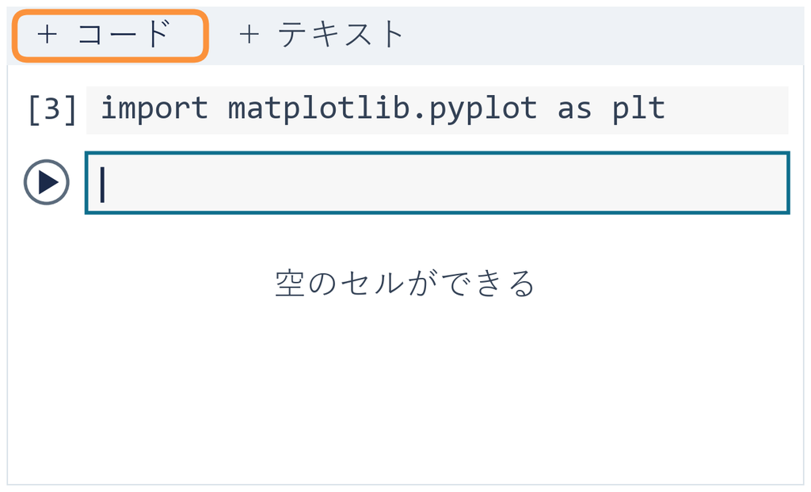

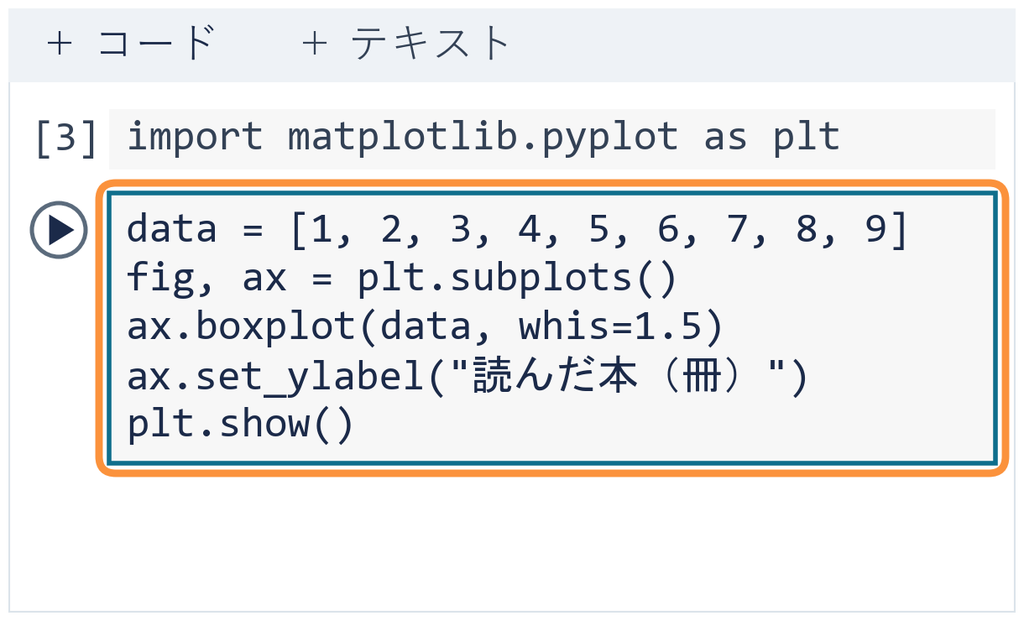

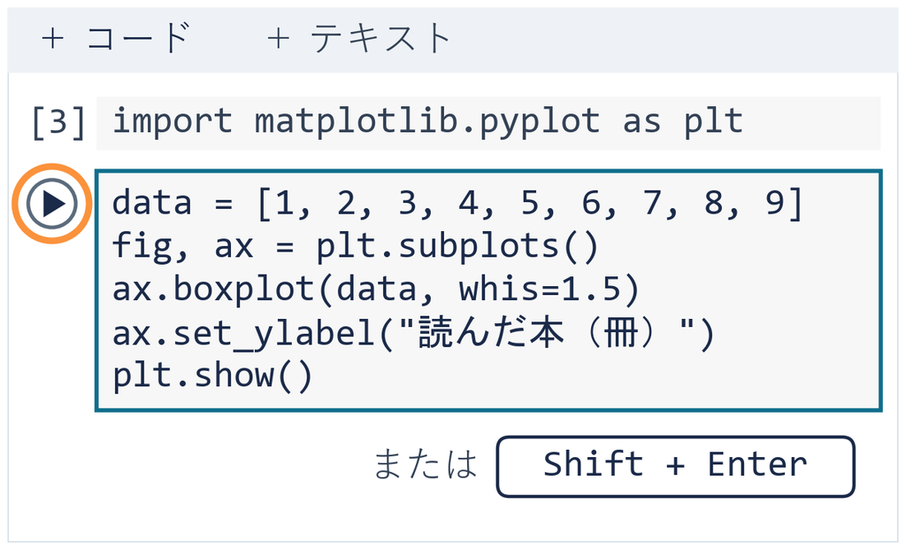

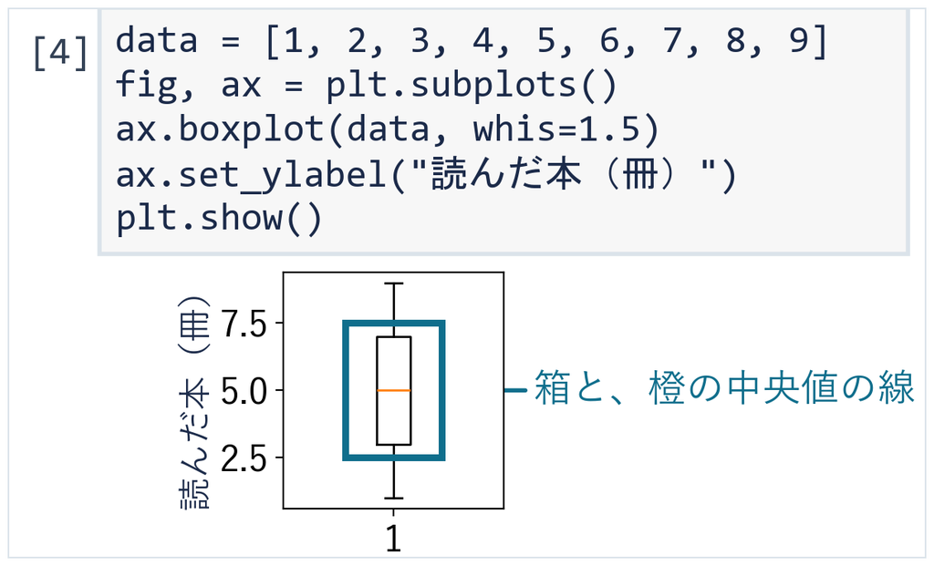

⏸ PAUSE 動画を止めて $2$ 分。図が出たら再生に戻る

## 写経 2 の 1 か所の変更

```python
data = [1, 2, 3, 4, 5, 6, 7, 8, 20]
fig, ax = plt.subplots()
ax.boxplot(data, whis=1.5)
ax.set_ylabel("読んだ本（冊）")
plt.show()
```

変えるのは **① データの最後の値だけ**（9 → 20）  
②〜⑤ は写経 1 と同じ。新しいセルに 5 行を写して実行  
※ `"` は半角（全角 `”` はエラー）

⏸ PAUSE 動画を止めて $2$ 分。2 つ目の図が出たら再生に戻る

## 写経 1 と写経 2 の出力

[figure not shown]

動いたのは上のひげと 20 の点だけ。目盛は 20 まで伸びた

## 実データの取り出し

```python
cs = df[df["year"] == 2023]
print(len(cs), "行")
cs[["prefecture", "C5401"]].head()
```

| 行 | 書き方 | 意味 |
| --- | --- | --- |
| 1 | `df[df["year"] == 2023]` | `==` で「年が 2023 と等しいか」を行ごとに調べ、 合う行だけ取り出して `cs` の名前 |
| 2 | `len(cs)` | 行の数を数える。47 県なので `47 行` と出る |
| 3 | `[["prefecture", "C5401"]]` | 県名と地価の 2 列を選ぶ。 続く `.head()` で先頭の 5 行を見る |

**写経せず、そのまま実行するセル**。`df` は最初に読んだ SSDSE-B の表  
※ `==` は「等しいか」を比べる記号。名前を付ける `=` とは別

## 写経 3 の地価のコード

```python
data = cs["C5401"] / 10000
fig, ax = plt.subplots()
ax.boxplot(data, whis=1.5)
ax.set_ylabel("住宅地の標準価格（万円/㎡）")
plt.show()
```

① データ：列 `C5401` を 10000 で割る（円/㎡ → 万円/㎡）  
④ 軸名：単位が変わったので字も変える  
② ③ ⑤ は写経 1・2 と同じ ※ `"` は半角

⏸ PAUSE 動画を止めて $2$ 分。47 行と図が出たら再生に戻る

## 写経 3 の出力

[figure not shown]

地価の箱ひげ図と同じ形。重なった点があり、図だけでは数えにくい

## 3 つの写経に共通の形

[figure not shown]

決まった 5 つの部品を、上から順にはめるパズル。  
変えるのはおもにデータの部品

## 演習 2-4 真ん中の値の変化と中央値

演習 2-4

真ん中の 5 冊の人を 20 冊にすると、中央値は動くか

```python
import numpy as np
data = [1, 2, 3, 4, 5, 6, 7, 8, 9]
print("並べた値:", sorted(data))
print("中央値  :", np.median(data))
```

1. **先に考える**：ⓐ 増える ⓑ 変わらない。並べ直して何番目かで
2. **写して変える**：案内の下に **＋ コード** でセルを足して写す  
   `data` の 5 番目の `5` を `20` に（1 か所）
3. **終わり**：答え欄に ⓐ か ⓑ と、出た中央値を書く ※ `"` は半角

⏸ PAUSE 動画を止めて $3$ 分。答えを書いたら再生に戻る

## 演習 2-4 の答え

[figure not shown]

答えは ⓐ 増える。真ん中を動かすと、並べた 5 番目が入れ替わる

## まとめ

- 箱ひげ図は、中央値・箱・ひげ・外れ値の 4 つの部品で読む
- 中央値は小さい順のまん中。  
  最大の値をいくら大きくしても動かない
- ひげは、箱から、境界の内側にある、いちばん端の値まで
- 境界＝箱の端 ± 1.5 × 箱の長さ。境界の外の値は点で描く
- 外れ値は誤りとは限らない。消す前に、出典と値の意味を確認
- コードは 5 つの部品のパズル。変えるのはおもにデータの部品

卒論のアンケートでも、離れた回答は消す前に確かめる  
機械に渡す前に、データを自分の目で確かめる